# Runs Expectancy in Baseball

From George Lindsey to an Ordinal Extension

Jim Albert, BGSU and Houston Astros

## Overview

**Part I: Foundations**

- The 24 base-out states
- George Lindsey (1963)
- The RE Matrix

**Part II: Applications**

- Valuing plays
- Strategy (bunt, steal, IBB)
- wOBA and RE24

**Part III: Beyond RE**

- Ordinal regression
- Multilevel modeling
- Covariates & clutch

Albert (2015), *Journal of Sports Analytics*, 1(1), 3–18

# Part I: Foundations

## The Half-Inning State

A **state** = outs + base configuration

- 3 out counts $\times$ 8 base configurations
- **24 distinct states**

```
State examples:
  (1--, 0 outs)   runner on 1st, nobody out
  (-23, 1 out)    2nd & 3rd, one out
  (123, 2 outs)   bases loaded, two outs
```

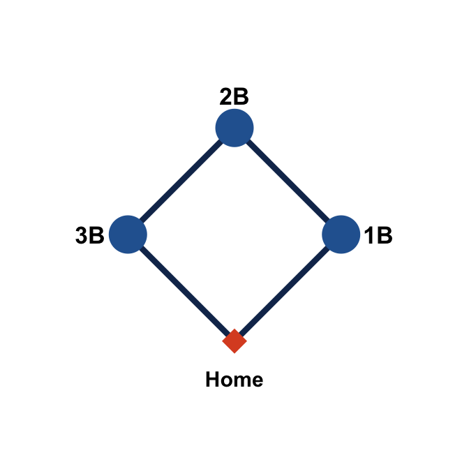

## George Lindsey (1963)

- Canadian defense researcher and baseball enthusiast
- First to study **run distributions** by game state
- Laid the groundwork for all modern RE analysis

> *Strategy decisions can be evaluated by tracking run distributions across states.*

**Key Papers**

Lindsey (1961)  
*Operations Research*

Lindsey (1963)  
*Operations Research*

## Runs Expectancy: Definition

$$\mathrm{RE}(b,o) = \mathbb{E}\bigl[\text{runs scored to end of inning} \mid \text{state } (b, o)\bigr]$$

- $b$ = base configuration, $o$ = number of outs
- Estimated empirically from Retrosheet play-by-play data
- **24 values** form the Runs Expectancy Matrix

## The RE Matrix (2019 Season)

| **Bases** | **0 Outs** | **1 Out** | **2 Outs** |
| --- | --- | --- | --- |
| `---` | 0.51 | 0.27 | 0.10 |
| `1--` | 0.88 | 0.52 | 0.22 |
| `-2-` | 1.14 | 0.71 | 0.33 |
| `12-` | 1.47 | 0.93 | 0.45 |
| `--3` | 1.35 | 0.97 | 0.38 |
| `1-3` | 1.77 | 1.18 | 0.51 |
| `-23` | 2.05 | 1.42 | 0.59 |
| `123` | 2.33 | 1.61 | 0.78 |

## Computing RE from Data

1. Get Retrosheet play-by-play files
2. Track runs scored from each state to end of half-inning
3. Average within each of the 24 states

```
Retrosheet: free play-by-play data back to the 1950s
Typically pool multiple seasons for stable estimates
```

## The Markov Chain View

- The 24 states + *inning over* form a **Markov chain**
- RE satisfies the recursion:

$$\mathrm{RE}(s) = \sum_{s'} P(s \to s') \cdot \bigl[r(s,s') + \mathrm{RE}(s')\bigr]$$

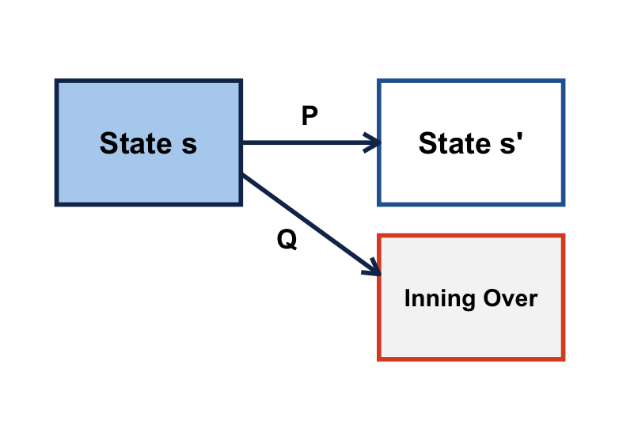

## A 60-Year History

| Year | Milestone |
| --- | --- |
| 1963 | Lindsey: run distributions by state |
| 1984 | Thorn & Palmer: *The Hidden Game of Baseball* |
| 2003 | Albert & Bennett: *Curve Ball* |
| 2007 | Tango, Lichtman & Dolphin: *The Book* |
| 2015 | Albert: *Beyond Runs Expectancy*, JOSA |

# Part II: Applications

## The Core Formula

$$\Delta\mathrm{RE} = \mathrm{RE}(s_{\text{after}}) - \mathrm{RE}(s_{\text{before}}) + \text{runs scored}$$

- $\Delta\mathrm{RE} > 0$: play **helped** the offense
- $\Delta\mathrm{RE} < 0$: play **hurt** the offense

## Linear Weights

Average $\Delta\mathrm{RE}$ over all instances of each event type:

| Event | Run Value |
| --- | --- |
| Home Run | $+1.40$ |
| Triple | $+1.05$ |
| Double | $+0.78$ |
| Single | $+0.47$ |
| Walk / HBP | $+0.32$ |
| Out | $-0.28$ |

## wOBA

Scale run values so that **league-average wOBA ≈ league OBP**:

$$\mathrm{wOBA} = \frac{w_{BB}\cdot BB + w_{1B}\cdot 1B + w_{2B}\cdot 2B + \cdots}{\mathrm{PA}}$$

- Weights derived from RE linear weights
- More informative than BA, OBP, or SLG alone

## RE24

Sum $\Delta\mathrm{RE}$ across all plate appearances in a season:

- **Context-sensitive**: a hit with RISP is worth more
- RE24 = $+22.4$ means +22.4 runs added above average
- Unlike wOBA, RE24 rewards clutch performance

## The Sacrifice Bunt

State change: $(\texttt{1--},\,0) \to (\texttt{-2-},\,1)$

$$\Delta\mathrm{RE} = 0.71 - 0.88 = \mathbf{-0.17}$$

The bunt **costs** 0.17 runs on average.

Only justified in specific late-game situations.

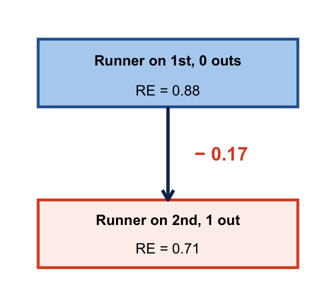

## Stolen Base Break-Even

Set expected $\Delta\mathrm{RE} = 0$ and solve for $p$:

$$p \cdot [\mathrm{RE}(\texttt{-2-},o) - \mathrm{RE}(\texttt{1--},o)] = (1-p) \cdot [\mathrm{RE}(\texttt{1--},o) - \mathrm{RE}(\texttt{---},o{+}1)]$$

[output not shown]

## The Intentional Walk

State change: $(\texttt{-2-},0) \to (\texttt{12-},0)$

$$\Delta\mathrm{RE} = 1.47 - 1.14 = +0.33 \text{ runs given up}$$

Worth it only if the win-probability gain from bypassing a dangerous hitter exceeds the RE cost.

## Leverage Index

$$\mathrm{LI} \approx \frac{\sigma^2(\text{WE change in current state})}{\sigma^2(\text{average across all states})}$$

- Measures **how much this PA matters** for winning
- Built on win expectancy, which is built on RE
- Used to deploy relievers and measure clutch context

## Inherited Runners & Lineup

**Inherited runners**

- Reliever RE24 penalizes stranded runners that score
- Cleanly separates starter vs. reliever responsibility

**Lineup construction**

- On-base ability most valuable at the top
- Power most valuable with runners on base
- Optimal lineups found via RE-based simulation

## RE Across Eras

RE values shift with the run environment:

| Era | Characteristic |
| --- | --- |
| Dead Ball (1910s) | Low RE; few extra-base hits |
| Offensive Boom (1990s–2000s) | RE peaked league-wide |
| Three True Outcomes (2015–) | Higher RE empty bases; lower with runners on |

# Part III: Beyond RE — Albert (2015)

## The Fundamental Limitation

$$\mathrm{RE}(\texttt{-23},\, 1) = 1.42$$

This tells us the **mean**. But managers need:

- $P(\text{score} = 0)$ — squeeze play decision
- $P(\text{score} \geq 2)$ — walk-off situation

**The mean alone cannot answer these questions.**

## Why Not a Standard Count Distribution?

Run-scoring has an **irregular shape**:

- Heavy mass at 0 and 1
- Long right tail

Poisson: requires mean = variance ✗  
Negative binomial: still fits poorly ✗  
Zero-inflated models: add complexity, still fail ✗

## The Ordinal Regression Approach

Treat runs as an **ordered categorical** outcome: $0, 1, 2, 3, 4{+}$

$$\log\!\left[\frac{P(Y \leq k \mid \mathbf{x})}{P(Y > k \mid \mathbf{x})}\right] = \alpha_k - \boldsymbol{\beta}^\top \mathbf{x}$$

- $\alpha_k$: thresholds (one per category boundary)
- $\boldsymbol{\beta}$: single coefficient vector (proportional odds)

## From Mean to Full Distribution

The ordinal model gives $P(Y = k \mid \text{state})$ for every $k$:

- $P(\text{score} \geq 1)$: probability of any run
- $P(\text{score} \geq 2)$: probability of a big inning
- Median, quantiles — not just mean

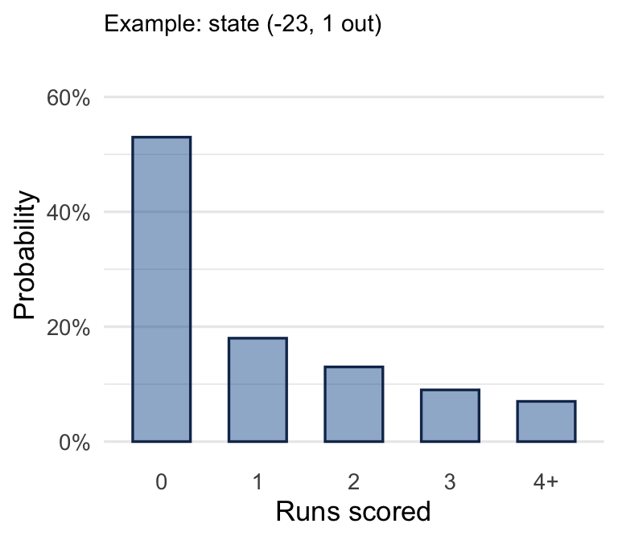

## The Runs Advantage Table

The ordinal coefficient $\beta_{(b,o)}$ measures how a state **shifts the run distribution upward**.

|  | RE Matrix | Runs Advantage |
| --- | --- | --- |
| Quantity | Mean runs | Ordinal coefficient |
| Information | Mean only | Full distribution |
| `120` vs `003` | `120` > `003` | `003` > `120` |
| Best use | General valuation | Tail-probability decisions |

## 003 vs 120: A Key Insight

- RE says `120` > `003` (higher *expected* runs)
- Runs Advantage says `003` > `120` (higher probability of *any* run)

The distributional view matters for squeeze plays, walk-offs, and one-run game strategy.

## Multilevel Modeling

Estimate all 30 teams **simultaneously**:

$$\mu_j \mid \mu, \sigma \;\sim\; N(\mu, \sigma^2), \quad j = 1, \ldots, 30$$

- Treats team abilities as **exchangeable**
- Shrinks extreme estimates toward the league mean
- Separates signal from noise

## Covariate 1: Ballpark Effects

$$\eta = \mu_j + \beta_\text{park}$$

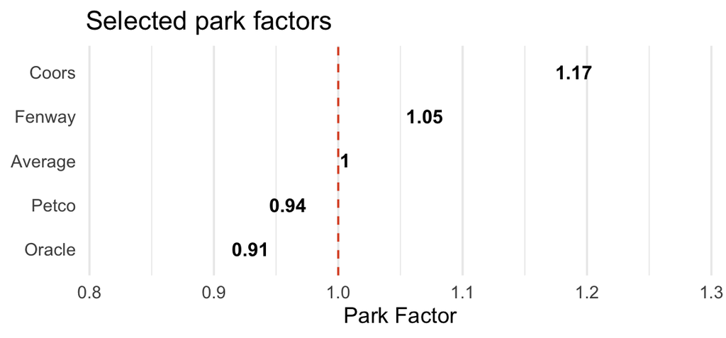

## Covariate 2: Pitcher Quality

- Modeled via opponent ERA or FIP
- Elite pitcher → run distribution shifts **left**
- Enables **opponent-adjusted** team offense ratings

## Covariate 3: Clutch / RISP

Does performance with **runners in scoring position** differ?

- RISP indicator added as a covariate
- Exchangeable priors shrink spurious team effects toward zero

**Finding:** Most team RISP variation is **random noise**.

## The Proportional Odds Assumption

Each covariate shifts **all** log-odds by the same amount $\beta$:

$$\log\frac{P(Y \leq k)}{P(Y > k)} = \alpha_k - \beta x$$

- One $\beta$ per covariate regardless of category $k$
- Parsimonious — far fewer parameters than unconstrained
- Albert finds this **well-supported** by MLB data

## Summary: Albert (2015)

1. **Full distribution** of runs scored, not just the mean
2. **Ordinal regression** — parsimonious, well-fitting
3. **30-team multilevel model** with shrinkage
4. **Covariates**: ballpark, pitcher quality, RISP
5. **Runs advantage table** — distributional RE counterpart
6. Much team RISP variation is noise

## Open Questions

**Modeling**

- Relax proportional-odds assumption
- Add batter identity
- Dynamic in-season updating

**Applications**

- Ordinal-based wOBA weights
- Strategy with distributional RE
- Real-time leverage index

## Conclusion

- The RE Matrix: **60 years** at the core of sabermetrics
- Powerful for play valuation, strategy, and metrics
- Its limitation: **the mean hides the distribution**
- Ordinal regression provides fuller picture

| RE Matrix | gives the *mean* |
| --- | --- |
| Beyond RE | gives the *distribution* |
| Multilevel | accounts for *context* |

> *“The runs expectancy table tells you the average. The ordinal model tells you the story.”*

## References

- Lindsey, G. (1963) “An Investigation of Strategies in Baseball”, *Operations Research* https://pubsonline.informs.org/doi/10.1287/opre.11.4.477
- My blog posts on Runs Expectancy https://bayesball.github.io/BLOG/Runs_Expectancy.html
- Albert, J. (2015) “Beyond Runs Expectancy”, *Journal of Sports Analytics* https://content.iospress.com/articles/journal-of-sports-analytics/jsa0001

## Analyzing Baseball Data with R (3rd Ed.) - AVAILABLE ONLINE

[figure not shown]

Runs Expectancy in Baseball